# PSYCH 260

2020-10-21 14:50:19

## Prelude

[video not shown]

2:55

## Today’s Topics

- Wrap-up on bipolar disorder
- Schizophrenia

## Mental illness lifetime prevalence

[figure not shown]

## Schizophrenia

[video not shown]

## Simulating the Experience

[video not shown]

## Overview

- Lifetime prevalence ~ 1/100
- ~1/3 chronic & severe
- Onset post-puberty, early adulthood
- Pervasive disturbance in mood, thinking, movement, action, memory, perception

## Screening (Yale PRIME test)

1. I think that I have felt that there are odd or unusual things going on that I can’t explain.
2. I think that I might be able to predict the future.
3. I may have felt that there could possibly be something interrupting or controlling my thoughts, feelings, or actions.

http://www.schizophrenia.com/sztest/primetest.pdf

## Screening (continued)

1. I get confused at times whether something I experience or perceive may be real or may be just part of my imagination or dreams.
2. I have thought that it might be possible that other people can read my mind, or that I can read other’s minds.
3. I wonder if people may be planning to hurt me or even may be about to hurt me.

## Historical background

- Bleuler
  - Coined term “schizophrenia” or “split mind”
  - NOT multiple personality disorder
- Kraeplin
  - Dementia Praecox and Paraphrenia (1919)
  - Emphasized developmental and hereditary origins

## “Positive” symptoms

- “Additions” to behavior
- Disordered thought
- Delusions of grandeur, persecution
- Hallucinations (usually auditory)
- Bizarre behavior

## “Negative” symptoms

- “Reductions” in behavior
- Poverty of speech
- Flat affect
- Social withdrawal
- Impaired executive function
- Anhedonia (loss of pleasure)
- Catatonia (reduced movement)

## Cognitive symptoms

- Memory
- Attention
- Planning, decision-making
- Social cognition
- Movement

## Biological bases

- Genetic disposition
- Brain abnormalities
- Developmental origins

## Genetic disposition

[figure not shown]

## But, no single gene…

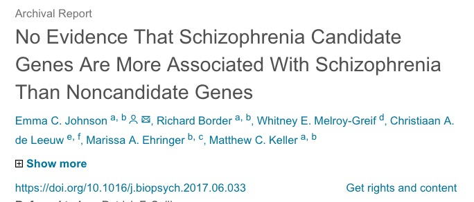

## Genes associated with schizophrenia at higher than chance levels

- *NOTCH4*, *TNF*:
  - Part of major histocompatibility complex (MHC), cell membrane specializations involved in the immune system
- *DRD2* (dopamine D2 receptor), *KCNN3* (Ca+ activated K+ channel), *GRM3* (metabotropic glutatmate receptor)

[(Johnson et al., 2017)](http://doi.org/10.1016/j.biopsych.2017.06.033)

## Ventricles larger, esp in males

[figure not shown]

## Cause or effect?

Ventricular enlargement increases across time [(Kempton, Stahl, Williams, & DeLisi, 2010)](http://doi.org/10.1016/j.schres.2010.03.036)

[figure not shown]

## Enlargement precedes diagnosis?

As in trajectories B or F

[figure not shown]

[(Kempton et al., 2010)](http://doi.org/10.1016/j.schres.2010.03.036)

## Hippocampus, amygdala, thalamus, nucleus accumbens smaller

- Related to ventricular enlargement?
- Early disturbance in brain development?

## [(Erp et al., 2015)](http://doi.org/10.1038/mp.2015.63)

[figure not shown]

https://www.nature.com/articles/mp201563/figures/1

## Rapid gray matter loss in adolescents?

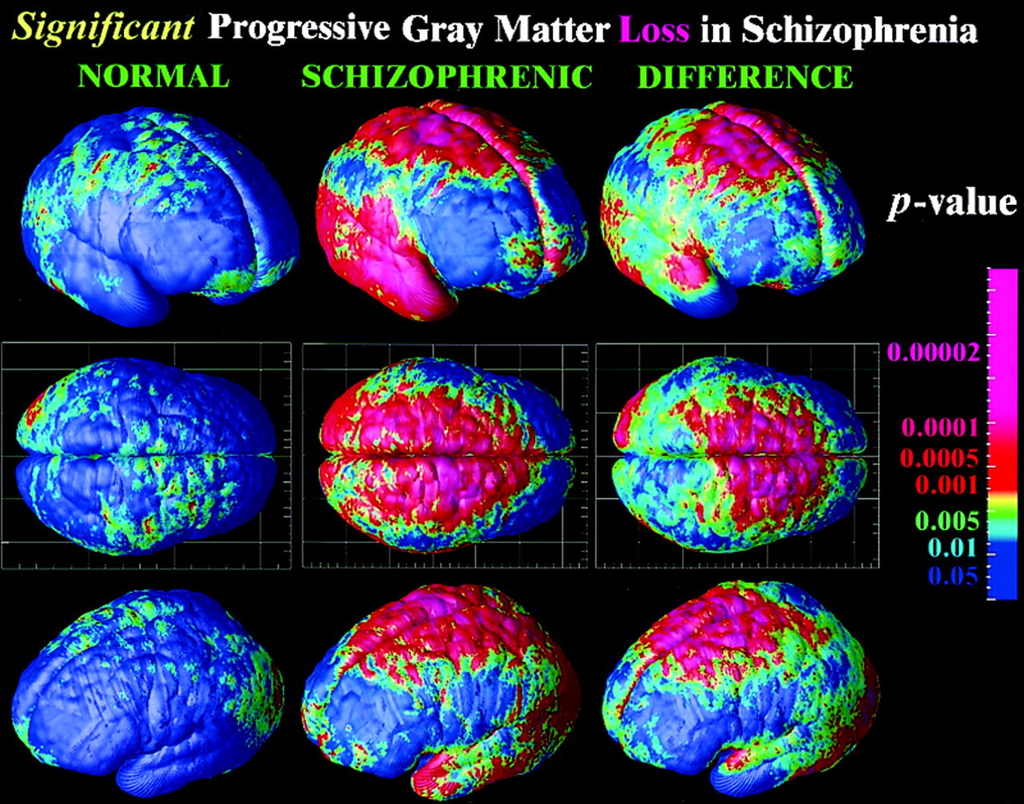

[(Thompson et al., 2001)](http://dx.doi.org/10.1073/pnas.201243998)

## Widespread disruption in white matter connectivity [(Kelly et al., 2017)](http://doi.org/10.1038/mp.2017.170)

[figure not shown]

https://www.nature.com/articles/mp2017170/figures/1

## White matter loss over age

[figure not shown]

[(Kochunov et al., 2016)](http://doi.org/10.1002/hbm.23336)

## Dopamine hypothesis

[figure not shown]

## Evidence for DA hypothesis

- DA (D2 receptor) antagonists (e.g. chlorpromazine)
  - improve positive symptoms
- *Typical antipsychotics* are DA D2 receptor antagonists
- DA agonists
  - amphetamine, cocaine, L-DOPA
  - mimic or exacerbate symptoms

## Tardive Dyskinesia a side effect of DA antagonists

[video not shown]

## Evidence against DA hypothesis…

- New, *atypical antipsychotics*
  - (e.g. Clozapine) INCREASE DA in frontal cortex, affect 5-HT
- Mixed evidence for high DA metabolite levels in CSF

## Glutamate hypothesis

- *Psychomimetic* drugs…
  - Phencyclidine (PCP), ketamine
  - NMDA receptor antagonists
- …can induce schizophrenia-like states
- Schizophrenia == *underactivation* of NMDA receptors?
  - NMDA receptor role in learning, plasticity
  - DG neurons in (Jiao et al., 2017) were glutamate-releasing.

## Early life stress increases risk

- Urban vs. rural living
- Exposure to infection *in utero*, other birth complications

## (Levine, Levav, Pugachova, Yoffe, & Becher, 2016)

- Children (N=51,233) of parents who born during Nazi era (1922-1945)
- Emigrated before (indirect exposure) or after (direct exposure) to Nazi era
- Children exposed to direct stress of Nazi era *in utero* or postnatally
  - Did **not** differ in rates of schizophrenia, but
  - Had higher rehospitalization rates

## [(Debost et al., 2015)](http://doi.org/10.1016/j.psyneuen.2015.05.013)

- Danish cohort (n=1,141,447)
- Exposure to early life stress
  - *in utero* did **not** increase risk of schizophrenia, but
  - but *exposure during infancy (0-2 years) increased risk*
- Increased risk associated with an allele of a cortisol-related gene

## Schizophrenia summed up

- Wide-ranging disturbance of mood, thought, action, perception
- Broad changes in brain structure, function, chemistry, development
- Dopamine hypothesis -> glutamate hypothesis
- Genetic (polygenic = multiple genes) risk + environmental factors
- One disorder or many?

## Next time…

- Emotion, happiness, and reward

## References

Debost, J.-C., Petersen, L., Grove, J., Hedemand, A., Khashan, A., Henriksen, T., … Mortensen, P. B. (2015). Investigating interactions between early life stress and two single nucleotide polymorphisms in HSD11B2 on the risk of schizophrenia. *Psychoneuroendocrinology*, *60*, 18–27. https://doi.org/10.1016/j.psyneuen.2015.05.013

Erp, T. G. M. van, Hibar, D. P., Rasmussen, J. M., Glahn, D. C., Pearlson, G. D., Andreassen, O. A., … Turner, J. A. (2015). Subcortical brain volume abnormalities in 2028 individuals with schizophrenia and 2540 healthy controls via the ENIGMA consortium. *Mol. Psychiatry*. https://doi.org/10.1038/mp.2015.63

Jiao, H.-F., Sun, X.-D., Bates, R., Xiong, L., Zhang, L., Liu, F., … Mei, L. (2017). Transmembrane protein 108 is required for glutamatergic transmission in dentate gyrus. *Proceedings of the National Academy of Sciences*, *114*(5), 1177–1182. https://doi.org/10.1073/pnas.1618213114

Johnson, E. C., Border, R., Melroy-Greif, W. E., Leeuw, C. A. de, Ehringer, M. A., & Keller, M. C. (2017). No evidence that schizophrenia candidate genes are more associated with schizophrenia than noncandidate genes. *Biol. Psychiatry*, *82*(10), 702–708. https://doi.org/10.1016/j.biopsych.2017.06.033

Kelly, S., Jahanshad, N., Zalesky, A., Kochunov, P., Agartz, I., Alloza, C., … Donohoe, G. (2017). Widespread white matter microstructural differences in schizophrenia across 4322 individuals: Results from the ENIGMA schizophrenia DTI working group. *Mol. Psychiatry*. https://doi.org/10.1038/mp.2017.170

Kempton, M. J., Stahl, D., Williams, S. C. R., & DeLisi, L. E. (2010). Progressive lateral ventricular enlargement in schizophrenia: A meta-analysis of longitudinal MRI studies. *Schizophr. Res.*, *120*(1-3), 54–62. https://doi.org/10.1016/j.schres.2010.03.036

Kochunov, P., Ganjgahi, H., Winkler, A., Kelly, S., Shukla, D. K., Du, X., … Hong, L. E. (2016). Heterochronicity of white matter development and aging explains regional patient control differences in schizophrenia. *Hum. Brain Mapp.*, *37*(12), 4673–4688. https://doi.org/10.1002/hbm.23336

Levine, S. Z., Levav, I., Pugachova, I., Yoffe, R., & Becher, Y. (2016). Transgenerational effects of genocide exposure on the risk and course of schizophrenia: A population-based study. *Schizophrenia Research*, *176*(2), 540–545. https://doi.org/10.1016/j.schres.2016.06.019

Thompson, P. M., Vidal, C., Giedd, J. N., Gochman, P., Blumenthal, J., Nicolson, R., … Rapoport, J. L. (2001). Mapping adolescent brain change reveals dynamic wave of accelerated gray matter loss in very early-onset schizophrenia. *Proceedings of the National Academy of Sciences*, *98*(20), 11650–11655. https://doi.org/10.1073/pnas.201243998